# Machine Learning Engineer Nanodegree

## Project: Capstone - Loan Default Risk

# Getting Started

```python
# Import libraries necessary for this project
import numpy as np
import pandas as pd
from time import time
from time import strftime
from datetime import datetime
import gc
import nbformat
import warnings
from nbconvert.preprocessors import ExecutePreprocessor
from IPython.display import display # Allows the use of display() for DataFrames

# matplotlib and seaborn for plotting
import matplotlib.pyplot as plt
import seaborn as sns

# sklearn preprocessing for dealing with categorical variables
from sklearn.preprocessing import LabelEncoder
from sklearn import metrics
from sklearn.metrics import confusion_matrix, classification_report
from sklearn.preprocessing import StandardScaler, MinMaxScaler, Imputer
from sklearn.model_selection import train_test_split
from sklearn_evaluation import plot as sklplot

# Suppress warnings
warnings.filterwarnings('ignore')

# fix random seed for reproducibility
RANDOM_SEED = 42
np.random.seed(RANDOM_SEED)

# try to prevent timeouts
ep = ExecutePreprocessor(timeout=-1)
```

# Getting the dataset

```python
app_train = pd.read_csv('./data/application_train.csv', quotechar='"')
app_test = pd.read_csv('./data/application_test.csv', quotechar='"')
```

```python
# Training data
print('Training data shape: ', app_train.shape)
app_train.head()
```

```
Training data shape:  (307511, 122)
```

|  | SK_ID_CURR | TARGET | NAME_CONTRACT_TYPE | CODE_GENDER | FLAG_OWN_CAR | FLAG_OWN_REALTY | CNT_CHILDREN | AMT_INCOME_TOTAL | AMT_CREDIT | AMT_ANNUITY | ... | FLAG_DOCUMENT_18 | FLAG_DOCUMENT_19 | FLAG_DOCUMENT_20 | FLAG_DOCUMENT_21 | AMT_REQ_CREDIT_BUREAU_HOUR | AMT_REQ_CREDIT_BUREAU_DAY | AMT_REQ_CREDIT_BUREAU_WEEK | AMT_REQ_CREDIT_BUREAU_MON | AMT_REQ_CREDIT_BUREAU_QRT | AMT_REQ_CREDIT_BUREAU_YEAR |
| --- | --- | --- | --- | --- | --- | --- | --- | --- | --- | --- | --- | --- | --- | --- | --- | --- | --- | --- | --- | --- | --- |
| 0 | 100002 | 1 | Cash loans | M | N | Y | 0 | 202500.0 | 406597.5 | 24700.5 | ... | 0 | 0 | 0 | 0 | 0.0 | 0.0 | 0.0 | 0.0 | 0.0 | 1.0 |
| 1 | 100003 | 0 | Cash loans | F | N | N | 0 | 270000.0 | 1293502.5 | 35698.5 | ... | 0 | 0 | 0 | 0 | 0.0 | 0.0 | 0.0 | 0.0 | 0.0 | 0.0 |
| 2 | 100004 | 0 | Revolving loans | M | Y | Y | 0 | 67500.0 | 135000.0 | 6750.0 | ... | 0 | 0 | 0 | 0 | 0.0 | 0.0 | 0.0 | 0.0 | 0.0 | 0.0 |
| 3 | 100006 | 0 | Cash loans | F | N | Y | 0 | 135000.0 | 312682.5 | 29686.5 | ... | 0 | 0 | 0 | 0 | NaN | NaN | NaN | NaN | NaN | NaN |
| 4 | 100007 | 0 | Cash loans | M | N | Y | 0 | 121500.0 | 513000.0 | 21865.5 | ... | 0 | 0 | 0 | 0 | 0.0 | 0.0 | 0.0 | 0.0 | 0.0 | 0.0 |

5 rows × 122 columns

```python
# Testing data features
print('Testing data shape: ', app_test.shape)
app_test.head()
```

```
Testing data shape:  (48744, 121)
```

|  | SK_ID_CURR | NAME_CONTRACT_TYPE | CODE_GENDER | FLAG_OWN_CAR | FLAG_OWN_REALTY | CNT_CHILDREN | AMT_INCOME_TOTAL | AMT_CREDIT | AMT_ANNUITY | AMT_GOODS_PRICE | ... | FLAG_DOCUMENT_18 | FLAG_DOCUMENT_19 | FLAG_DOCUMENT_20 | FLAG_DOCUMENT_21 | AMT_REQ_CREDIT_BUREAU_HOUR | AMT_REQ_CREDIT_BUREAU_DAY | AMT_REQ_CREDIT_BUREAU_WEEK | AMT_REQ_CREDIT_BUREAU_MON | AMT_REQ_CREDIT_BUREAU_QRT | AMT_REQ_CREDIT_BUREAU_YEAR |
| --- | --- | --- | --- | --- | --- | --- | --- | --- | --- | --- | --- | --- | --- | --- | --- | --- | --- | --- | --- | --- | --- |
| 0 | 100001 | Cash loans | F | N | Y | 0 | 135000.0 | 568800.0 | 20560.5 | 450000.0 | ... | 0 | 0 | 0 | 0 | 0.0 | 0.0 | 0.0 | 0.0 | 0.0 | 0.0 |
| 1 | 100005 | Cash loans | M | N | Y | 0 | 99000.0 | 222768.0 | 17370.0 | 180000.0 | ... | 0 | 0 | 0 | 0 | 0.0 | 0.0 | 0.0 | 0.0 | 0.0 | 3.0 |
| 2 | 100013 | Cash loans | M | Y | Y | 0 | 202500.0 | 663264.0 | 69777.0 | 630000.0 | ... | 0 | 0 | 0 | 0 | 0.0 | 0.0 | 0.0 | 0.0 | 1.0 | 4.0 |
| 3 | 100028 | Cash loans | F | N | Y | 2 | 315000.0 | 1575000.0 | 49018.5 | 1575000.0 | ... | 0 | 0 | 0 | 0 | 0.0 | 0.0 | 0.0 | 0.0 | 0.0 | 3.0 |
| 4 | 100038 | Cash loans | M | Y | N | 1 | 180000.0 | 625500.0 | 32067.0 | 625500.0 | ... | 0 | 0 | 0 | 0 | NaN | NaN | NaN | NaN | NaN | NaN |

5 rows × 121 columns

# Phase 1

Leveraging only application_{train|test} files

# Exploratory data analysis

```python
# Number of each type of column
app_train.dtypes.value_counts()
```

```
float64    65
int64      41
object     16
dtype: int64
```

```python
# Number of unique classes in each object column
app_train.select_dtypes('object').apply(pd.Series.nunique, axis = 0)
```

```
NAME_CONTRACT_TYPE             2
CODE_GENDER                    3
FLAG_OWN_CAR                   2
FLAG_OWN_REALTY                2
NAME_TYPE_SUITE                7
NAME_INCOME_TYPE               8
NAME_EDUCATION_TYPE            5
NAME_FAMILY_STATUS             6
NAME_HOUSING_TYPE              6
OCCUPATION_TYPE               18
WEEKDAY_APPR_PROCESS_START     7
ORGANIZATION_TYPE             58
FONDKAPREMONT_MODE             4
HOUSETYPE_MODE                 3
WALLSMATERIAL_MODE             7
EMERGENCYSTATE_MODE            2
dtype: int64
```

```python
# checking missing data - show the percent missing values (higher number, more missing)
total = app_train.isnull().sum().sort_values(ascending = False)
percent = (app_train.isnull().sum()/app_train.isnull().count()*100).sort_values(ascending = False)
missing_appl_train_data  = pd.concat([total, percent], axis=1, keys=['Total', 'Percent'])
missing_appl_train_data.head(50)
```

|  | Total | Percent |
| --- | --- | --- |
| COMMONAREA_MEDI | 214865 | 69.872297 |
| COMMONAREA_AVG | 214865 | 69.872297 |
| COMMONAREA_MODE | 214865 | 69.872297 |
| NONLIVINGAPARTMENTS_MODE | 213514 | 69.432963 |
| NONLIVINGAPARTMENTS_MEDI | 213514 | 69.432963 |
| NONLIVINGAPARTMENTS_AVG | 213514 | 69.432963 |
| FONDKAPREMONT_MODE | 210295 | 68.386172 |
| LIVINGAPARTMENTS_MEDI | 210199 | 68.354953 |
| LIVINGAPARTMENTS_MODE | 210199 | 68.354953 |
| LIVINGAPARTMENTS_AVG | 210199 | 68.354953 |
| FLOORSMIN_MEDI | 208642 | 67.848630 |
| FLOORSMIN_MODE | 208642 | 67.848630 |
| FLOORSMIN_AVG | 208642 | 67.848630 |
| YEARS_BUILD_MEDI | 204488 | 66.497784 |
| YEARS_BUILD_AVG | 204488 | 66.497784 |
| YEARS_BUILD_MODE | 204488 | 66.497784 |
| OWN_CAR_AGE | 202929 | 65.990810 |
| LANDAREA_MODE | 182590 | 59.376738 |
| LANDAREA_AVG | 182590 | 59.376738 |
| LANDAREA_MEDI | 182590 | 59.376738 |
| BASEMENTAREA_MEDI | 179943 | 58.515956 |
| BASEMENTAREA_AVG | 179943 | 58.515956 |
| BASEMENTAREA_MODE | 179943 | 58.515956 |
| EXT_SOURCE_1 | 173378 | 56.381073 |
| NONLIVINGAREA_MEDI | 169682 | 55.179164 |
| NONLIVINGAREA_AVG | 169682 | 55.179164 |
| NONLIVINGAREA_MODE | 169682 | 55.179164 |
| ELEVATORS_MODE | 163891 | 53.295980 |
| ELEVATORS_AVG | 163891 | 53.295980 |
| ELEVATORS_MEDI | 163891 | 53.295980 |
| WALLSMATERIAL_MODE | 156341 | 50.840783 |
| APARTMENTS_MODE | 156061 | 50.749729 |
| APARTMENTS_AVG | 156061 | 50.749729 |
| APARTMENTS_MEDI | 156061 | 50.749729 |
| ENTRANCES_MEDI | 154828 | 50.348768 |
| ENTRANCES_MODE | 154828 | 50.348768 |
| ENTRANCES_AVG | 154828 | 50.348768 |
| LIVINGAREA_MEDI | 154350 | 50.193326 |
| LIVINGAREA_MODE | 154350 | 50.193326 |
| LIVINGAREA_AVG | 154350 | 50.193326 |
| HOUSETYPE_MODE | 154297 | 50.176091 |
| FLOORSMAX_MODE | 153020 | 49.760822 |
| FLOORSMAX_MEDI | 153020 | 49.760822 |
| FLOORSMAX_AVG | 153020 | 49.760822 |
| YEARS_BEGINEXPLUATATION_MEDI | 150007 | 48.781019 |
| YEARS_BEGINEXPLUATATION_AVG | 150007 | 48.781019 |
| YEARS_BEGINEXPLUATATION_MODE | 150007 | 48.781019 |
| TOTALAREA_MODE | 148431 | 48.268517 |
| EMERGENCYSTATE_MODE | 145755 | 47.398304 |
| OCCUPATION_TYPE | 96391 | 31.345545 |

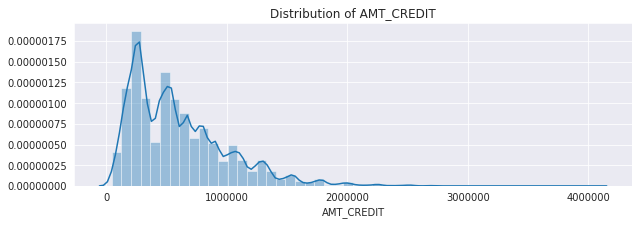

```python
sns.set_style("darkgrid")
plt.figure(figsize=(10,3))
plt.title("Distribution of AMT_CREDIT")
ax = sns.distplot(app_train["AMT_CREDIT"])
```

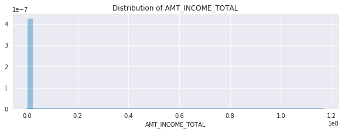

```python
plt.figure(figsize=(10,3))
plt.title("Distribution of AMT_INCOME_TOTAL")
ax = sns.distplot(app_train["AMT_INCOME_TOTAL"].dropna())
```

```python
inc_log_transformed =pd.DataFrame()
inc_log_transformed['AMT_INCOME_TOTAL'] = app_train['AMT_INCOME_TOTAL'].apply(lambda x: np.log(x + 1))
```

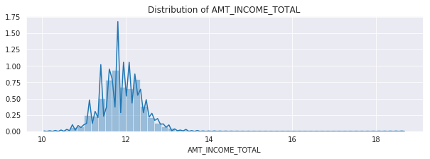

```python
plt.figure(figsize=(10,3))
plt.title("Distribution of AMT_INCOME_TOTAL")
ax = sns.distplot(inc_log_transformed["AMT_INCOME_TOTAL"].dropna())
```

Let's log transfor the amt AMT_INCOME_TOTAL before we scale, do this for both train and test

```python
app_train['AMT_INCOME_TOTAL'] = app_train['AMT_INCOME_TOTAL'].apply(lambda x: np.log(x + 1))
app_test['AMT_INCOME_TOTAL'] = app_test['AMT_INCOME_TOTAL'].apply(lambda x: np.log(x + 1))
```

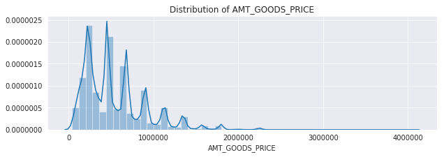

```python
plt.figure(figsize=(10,3))
plt.title("Distribution of AMT_GOODS_PRICE")
ax = sns.distplot(app_train["AMT_GOODS_PRICE"].dropna())
```

```python
(app_train['DAYS_BIRTH'] / -365).describe()
```

```
count    307511.000000
mean         43.936973
std          11.956133
min          20.517808
25%          34.008219
50%          43.150685
75%          53.923288
max          69.120548
Name: DAYS_BIRTH, dtype: float64
```

```python
app_train['DAYS_EMPLOYED'].describe()
```

```
count    307511.000000
mean      63815.045904
std      141275.766519
min      -17912.000000
25%       -2760.000000
50%       -1213.000000
75%        -289.000000
max      365243.000000
Name: DAYS_EMPLOYED, dtype: float64
```

```python
anom = app_train[app_train['DAYS_EMPLOYED'] == 365243]
non_anom = app_train[app_train['DAYS_EMPLOYED'] != 365243]
print('The non-anomalies default on %0.2f%% of loans' % (100 * non_anom['TARGET'].mean()))
print('The anomalies default on %0.2f%% of loans' % (100 * anom['TARGET'].mean()))
print('There are %d anomalous days of employment' % len(anom))
```

```
The non-anomalies default on 8.66% of loans
The anomalies default on 5.40% of loans
There are 55374 anomalous days of employment
```

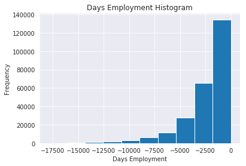

```python
# Create an anomalous flag column
app_train['DAYS_EMPLOYED_ANOM'] = app_train["DAYS_EMPLOYED"] == 365243

# Replace the anomalous values with nan
app_train['DAYS_EMPLOYED'].replace({365243: np.nan}, inplace = True)

app_train['DAYS_EMPLOYED'].plot.hist(title = 'Days Employment Histogram');
plt.xlabel('Days Employment');
```

```python
#do same for test
app_test['DAYS_EMPLOYED_ANOM'] = app_test["DAYS_EMPLOYED"] == 365243
app_test["DAYS_EMPLOYED"].replace({365243: np.nan}, inplace = True)

print('There are %d anomalies in the test data out of %d entries' % (app_test["DAYS_EMPLOYED_ANOM"].sum(), len(app_test)))
```

```
There are 9274 anomalies in the test data out of 48744 entries
```

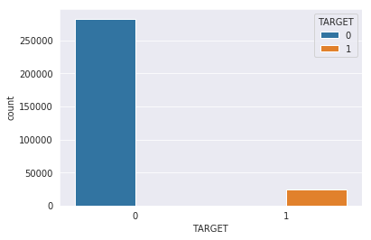

```python
sns.countplot(x='TARGET',hue='TARGET', data=app_train)
```

| NAME_FAMILY_STATUS | Repayers | Defaulters |
| --- | --- | --- |
| Civil marriage | 26814 | 2961 |
| Married | 181582 | 14850 |
| Separated | 18150 | 1620 |
| Single / not married | 40987 | 4457 |
| Unknown | 2 | 0 |
| Widow | 15151 | 937 |

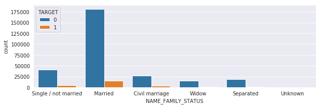

```python
plt.figure(figsize=(10,3))
sns.countplot(x = "NAME_FAMILY_STATUS", hue = "TARGET", data = app_train)
fam_stat_target = pd.crosstab(app_train['NAME_FAMILY_STATUS'], app_train['TARGET'])
kind_of_applicant = ("Repayers", "Defaulters")
fam_stat_target.columns = kind_of_applicant
fam_stat_target
```

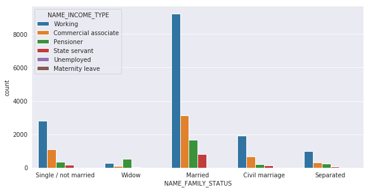

```python
plt.figure(figsize= (10,5))# plot the figure
plt.show(sns.countplot(x = "NAME_FAMILY_STATUS",
                       hue = "NAME_INCOME_TYPE" ,
                       # filter the train set by using TARGET column == 1
                       data= app_train.loc[app_train['TARGET'] == 1]))
```

```python
dcorrel = app_train.corr()['TARGET'].sort_values()
print('Most Positive Correlations:\n', dcorrel.tail(15))
print('\nMost Negative Correlations:\n', dcorrel.head(15))
```

```
Most Positive Correlations:
 DEF_30_CNT_SOCIAL_CIRCLE       0.032248
LIVE_CITY_NOT_WORK_CITY        0.032518
OWN_CAR_AGE                    0.037612
DAYS_REGISTRATION              0.041975
FLAG_DOCUMENT_3                0.044346
REG_CITY_NOT_LIVE_CITY         0.044395
FLAG_EMP_PHONE                 0.045982
REG_CITY_NOT_WORK_CITY         0.050994
DAYS_ID_PUBLISH                0.051457
DAYS_LAST_PHONE_CHANGE         0.055218
REGION_RATING_CLIENT           0.058899
REGION_RATING_CLIENT_W_CITY    0.060893
DAYS_EMPLOYED                  0.074958
DAYS_BIRTH                     0.078239
TARGET                         1.000000
Name: TARGET, dtype: float64

Most Negative Correlations:
 EXT_SOURCE_3                 -0.178919
EXT_SOURCE_2                 -0.160472
EXT_SOURCE_1                 -0.155317
DAYS_EMPLOYED_ANOM           -0.045987
FLOORSMAX_AVG                -0.044003
FLOORSMAX_MEDI               -0.043768
FLOORSMAX_MODE               -0.043226
AMT_GOODS_PRICE              -0.039645
REGION_POPULATION_RELATIVE   -0.037227
ELEVATORS_AVG                -0.034199
ELEVATORS_MEDI               -0.033863
FLOORSMIN_AVG                -0.033614
FLOORSMIN_MEDI               -0.033394
LIVINGAREA_AVG               -0.032997
LIVINGAREA_MEDI              -0.032739
Name: TARGET, dtype: float64
```

> **We will add a 4 engineered features based on research, we will add the here before we do the train-test-split**

```python
# Aggregate the supplemental datasets so that they have a single row per customer

# add a few new features
app_train['LOAN_INCOME_RATIO'] = app_train['AMT_CREDIT'] / app_train['AMT_INCOME_TOTAL']
app_train['ANNUITY_INCOME_RATIO'] = app_train['AMT_ANNUITY'] / app_train['AMT_INCOME_TOTAL']
app_train['ANNUITY LENGTH'] = app_train['AMT_CREDIT'] / app_train['AMT_ANNUITY']
app_train['DAYS_EMPLOYED_PERCENT'] = app_train['DAYS_EMPLOYED'] / app_train['DAYS_BIRTH']

print('Combined train & test shape before merging  = {}'.format(app_train.shape))
```

```
Combined train & test shape before merging  = (307511, 127)
```

```python
# Aggregate the supplemental datasets so that they have a single row per customer

# add a few new features
app_test['LOAN_INCOME_RATIO'] = app_test['AMT_CREDIT'] / app_test['AMT_INCOME_TOTAL']
app_test['ANNUITY_INCOME_RATIO'] = app_test['AMT_ANNUITY'] / app_test['AMT_INCOME_TOTAL']
app_test['ANNUITY LENGTH'] = app_test['AMT_CREDIT'] / app_test['AMT_ANNUITY']
app_test['DAYS_EMPLOYED_PERCENT'] = app_test['DAYS_EMPLOYED'] / app_test['DAYS_BIRTH']

print('Combined train & test shape before merging  = {}'.format(app_test.shape))
```

```
Combined train & test shape before merging  = (48744, 126)
```

```python
print('Training data shape: ', app_train.shape)
print('Testing data shape: ', app_test.shape)
```

```
Training data shape:  (307511, 127)
Testing data shape:  (48744, 126)
```

> Before we begin to try other models we will check for columns which have a high degree of null values and we will remove them in order to reduce the number of dimensions as this can lead to overfitting and slow performance.

```python
total = app_train.isnull().sum().sort_values(ascending = False)
percent = (app_train.isnull().sum()/app_train.isnull().count()*100).sort_values(ascending = False)
missing_appl_train_data  = pd.concat([total, percent], axis=1, keys=['Total', 'Percent'])
missing_appl_train_data.head(50)
```

|  | Total | Percent |
| --- | --- | --- |
| COMMONAREA_MEDI | 214865 | 69.872297 |
| COMMONAREA_MODE | 214865 | 69.872297 |
| COMMONAREA_AVG | 214865 | 69.872297 |
| NONLIVINGAPARTMENTS_MODE | 213514 | 69.432963 |
| NONLIVINGAPARTMENTS_AVG | 213514 | 69.432963 |
| NONLIVINGAPARTMENTS_MEDI | 213514 | 69.432963 |
| FONDKAPREMONT_MODE | 210295 | 68.386172 |
| LIVINGAPARTMENTS_MODE | 210199 | 68.354953 |
| LIVINGAPARTMENTS_MEDI | 210199 | 68.354953 |
| LIVINGAPARTMENTS_AVG | 210199 | 68.354953 |
| FLOORSMIN_MODE | 208642 | 67.848630 |
| FLOORSMIN_MEDI | 208642 | 67.848630 |
| FLOORSMIN_AVG | 208642 | 67.848630 |
| YEARS_BUILD_MODE | 204488 | 66.497784 |
| YEARS_BUILD_MEDI | 204488 | 66.497784 |
| YEARS_BUILD_AVG | 204488 | 66.497784 |
| OWN_CAR_AGE | 202929 | 65.990810 |
| LANDAREA_AVG | 182590 | 59.376738 |
| LANDAREA_MEDI | 182590 | 59.376738 |
| LANDAREA_MODE | 182590 | 59.376738 |
| BASEMENTAREA_MEDI | 179943 | 58.515956 |
| BASEMENTAREA_AVG | 179943 | 58.515956 |
| BASEMENTAREA_MODE | 179943 | 58.515956 |
| EXT_SOURCE_1 | 173378 | 56.381073 |
| NONLIVINGAREA_MEDI | 169682 | 55.179164 |
| NONLIVINGAREA_AVG | 169682 | 55.179164 |
| NONLIVINGAREA_MODE | 169682 | 55.179164 |
| ELEVATORS_MEDI | 163891 | 53.295980 |
| ELEVATORS_MODE | 163891 | 53.295980 |
| ELEVATORS_AVG | 163891 | 53.295980 |
| WALLSMATERIAL_MODE | 156341 | 50.840783 |
| APARTMENTS_MODE | 156061 | 50.749729 |
| APARTMENTS_MEDI | 156061 | 50.749729 |
| APARTMENTS_AVG | 156061 | 50.749729 |
| ENTRANCES_MODE | 154828 | 50.348768 |
| ENTRANCES_MEDI | 154828 | 50.348768 |
| ENTRANCES_AVG | 154828 | 50.348768 |
| LIVINGAREA_MODE | 154350 | 50.193326 |
| LIVINGAREA_AVG | 154350 | 50.193326 |
| LIVINGAREA_MEDI | 154350 | 50.193326 |
| HOUSETYPE_MODE | 154297 | 50.176091 |
| FLOORSMAX_MEDI | 153020 | 49.760822 |
| FLOORSMAX_MODE | 153020 | 49.760822 |
| FLOORSMAX_AVG | 153020 | 49.760822 |
| YEARS_BEGINEXPLUATATION_MEDI | 150007 | 48.781019 |
| YEARS_BEGINEXPLUATATION_AVG | 150007 | 48.781019 |
| YEARS_BEGINEXPLUATATION_MODE | 150007 | 48.781019 |
| TOTALAREA_MODE | 148431 | 48.268517 |
| EMERGENCYSTATE_MODE | 145755 | 47.398304 |
| OCCUPATION_TYPE | 96391 | 31.345545 |

```python
#Determine the features that are over x% null,
null_counts = app_train.isnull().sum()
null_counts = null_counts[null_counts > 0]
null_ratios = null_counts / len(app_train)
```

```python
# Drop columns over x% null
drop_list = []
null_thresh = .25
null_cols = null_ratios[null_ratios > null_thresh].index
app_train.drop(null_cols, axis=1, inplace=True)
app_test.drop(null_cols, axis=1, inplace=True)
print('Columns dropped for being over {}% null:'.format(100*null_thresh))
for col in null_cols:
    drop_list.append(col)

print(drop_list)
```

[output not shown]

```python
print('Shape after dropping high null cols = {}'.format(app_train.shape))
```

```
Shape after dropping high null cols = (307511, 77)
```

```python
print('Shape after dropping high null cols = {}'.format(app_test.shape))
```

```
Shape after dropping high null cols = (48744, 76)
```

> Now we will encode and impute

```python
#drop the key's before we encode but save them first, so we have them later
key_train = app_train['SK_ID_CURR']
key_test  = app_test['SK_ID_CURR']
app_train = app_train.drop(columns = ['SK_ID_CURR'])
app_test = app_test.drop(columns = ['SK_ID_CURR'])
```

```python
# Create a label encoder object
le = LabelEncoder()
le_count = 0

# Iterate through the columns
for col in app_train:
    if app_train[col].dtype == 'object':
        # If 2 or fewer unique categories
        if len(list(app_train[col].unique())) <= 2:
            # Train on the training data
            le.fit(app_train[col])
            # Transform both training and testing data
            app_train[col] = le.transform(app_train[col])
            app_test[col] = le.transform(app_test[col])

            # Keep track of how many columns were label encoded
            le_count += 1

print('%d columns were label encoded.' % le_count)
```

```
3 columns were label encoded.
```

```python
print('Training data shape: ', app_train.shape)
print('Testing data shape: ', app_test.shape)
```

```
Training data shape:  (307511, 76)
Testing data shape:  (48744, 75)
```

```python
#get dummies for categorical features
app_train = pd.get_dummies(app_train)
app_test = pd.get_dummies(app_test)
```

```python
print('Training data shape: ', app_train.shape)
print('Testing data shape: ', app_test.shape)
```

```
Training data shape:  (307511, 168)
Testing data shape:  (48744, 164)
```

```python
train_labels = app_train['TARGET']

# Align the training and testing data, keep only columns present in both dataframes (we will lose target since it's not in test)
app_train, app_test = app_train.align(app_test, join = 'inner', axis = 1)

# Add the target back in
app_train['TARGET'] = train_labels
```

```python
print('Training data shape: ', app_train.shape)
print('Testing data shape: ', app_test.shape)
```

```
Training data shape:  (307511, 165)
Testing data shape:  (48744, 164)
```

```python
from sklearn.preprocessing import MinMaxScaler, Imputer

# Drop the target from the training data
if 'TARGET' in app_train:
    train = app_train.drop(columns = ['TARGET'])
else:
    train = app_train.copy()


imputed_features = Imputer(strategy = 'median').fit_transform(train.values)
imputed_features_df = pd.DataFrame(imputed_features, index=train.index, columns=train.columns)
scaled_features = MinMaxScaler(feature_range = (0, 1)).fit_transform(imputed_features_df.values)
train = pd.DataFrame(scaled_features, index=imputed_features_df.index, columns=imputed_features_df.columns)

imputed_features = Imputer(strategy = 'median').fit_transform(app_test.values)
imputed_features_df = pd.DataFrame(imputed_features, index=app_test.index, columns=app_test.columns)
scaled_features = MinMaxScaler(feature_range = (0, 1)).fit_transform(imputed_features_df.values)
test = pd.DataFrame(scaled_features, index=imputed_features_df.index, columns=imputed_features_df.columns)
```

```python
# Add the target back in
train['TARGET'] = train_labels
```

```python
print('Training data shape: ', train.shape)
print('Testing data shape: ', test.shape)
```

```
Training data shape:  (307511, 165)
Testing data shape:  (48744, 164)
```

## Implementation: Initial Model Evaluation

```python
from sklearn.model_selection import GridSearchCV
from sklearn.model_selection import RandomizedSearchCV
from sklearn.metrics import confusion_matrix
from sklearn.metrics import classification_report
import scikitplot as skplt
import matplotlib.pyplot as plt


from time import time
from operator import itemgetter
```

```python
# Split the data into features and target label
target = train['TARGET'].astype(np.int64)
```

```python
features = train.drop('TARGET', axis = 1)
```

```python
# Create a validation set to check training performance
XTrain, XTest, YTrain, YTest = train_test_split(features, target, test_size=0.2, random_state=RANDOM_SEED)
```

```python
# Show the results of the split
print("Training set has {} samples.".format(XTrain.shape[0]))
print("Testing set has {} samples.".format(XTest.shape[0]))
```

```
Training set has 246008 samples.
Testing set has 61503 samples.
```

```python
XTrain.shape, XTest.shape, YTrain.shape, YTest.shape
```

```
((246008, 164), (61503, 164), (246008,), (61503,))
```

> Let's define a few function we'll use later and through out the notebook to perform hyperparameter searches, perform fitting, display/report, and time our results.

```python
# create a function to perform grid search with cross validation and returns the accuracy values
def GridSearch_BestParam(X, y, clf, param_grid,cv=None):
    grid_search = GridSearchCV(clf,
                        param_grid=param_grid,cv=cv)
    start= time()
    grid_search.fit(X,y)
    top_params=grid_search.grid_scores_
    return top_params
```

```python
from scipy.stats import randint as sp_randint
from sklearn.datasets import load_digits
from sklearn.model_selection import RandomizedSearchCV
from time import time

def report(results, n_top=3):
    for i in range(1, n_top + 1):
        candidates = np.flatnonzero(results['rank_test_score'] == i)
        for candidate in candidates:
            print("Model with rank: {0}".format(i))
            print("Mean validation score: {0:.3f} (std: {1:.3f})".format(
                  results['mean_test_score'][candidate],
                  results['std_test_score'][candidate]))
            print("Parameters: {0}".format(results['params'][candidate]))
            print("")
```

```python
# create a function to perform grid search with cross validation and returns the accuracy values
def Fit_Report(clf, XTrain, YTrain, XTest, YTest):

    clf.fit(XTrain, YTrain)
    YTest_Pred = clf.predict(XTest)
    YTest_Pred_Probs = clf.predict_proba(XTest)
    print(classification_report(YTest,YTest_Pred))

    accuracy=clf.score(XTrain, YTrain)
    print("\nPredictor: [Accuracy score: {:.4f}]".format(accuracy))


    print("\nConfusion Matrix: ")
    sklplot.confusion_matrix(YTest, YTest_Pred)
    plt.show()

    print("\nROC Curve and AUC Plot: ")
    y_true = YTest
    y_probas = YTest_Pred_Probs
    skplt.metrics.plot_roc_curve(y_true, y_probas)
    plt.show()

    return
```

```python
def seconds_converter(seconds):
    '''Used for trip_duration(city_data), converts seconds into (hours minutes seconds)
    Args:
        seconds -- amount of seconds
    Returns:
        (str) Tells user the amount of time
    '''
    # divmod docs: https://docs.python.org/2/library/functions.html#divmod
    m, s = divmod(seconds, 60)
    h, m = divmod(m, 60)
    return '%d Days %02d Minutes and %02d seconds' % (h, m, s)
```

### Logistic Regression

```python
from sklearn.linear_model import LogisticRegression
```

```python
lrmodel = LogisticRegression()
lrmodel
```

```
LogisticRegression(C=1.0, class_weight=None, dual=False, fit_intercept=True,
          intercept_scaling=1, max_iter=100, multi_class='ovr', n_jobs=1,
          penalty='l2', random_state=None, solver='liblinear', tol=0.0001,
          verbose=0, warm_start=False)
```

```python
#try other solvers, and iters
#param_grid = {'C': [.0001, .0005, 0.001], 'max_iter':[50,100]}
param_grid = {'C': [.0001], 'max_iter':[50]}
```

```python
top_param = GridSearch_BestParam(XTrain, YTrain, lrmodel, param_grid, cv=None)
top_score = sorted(top_param,key=itemgetter(1), reverse=True)
```

```python
#get the top score after sorting
paramCV = top_score[0].parameters
#print the params with best accuracy
paramCV
```

```
{'C': 0.0001, 'max_iter': 50}
```

```python
best_model = LogisticRegression(C=paramCV['C'], max_iter=paramCV['max_iter'])
```

```
             precision    recall  f1-score   support

          0       0.92      1.00      0.96     56554
          1       0.00      0.00      0.00      4949

avg / total       0.85      0.92      0.88     61503


Predictor: [Accuracy score: 0.9192]

Confusion Matrix:
```

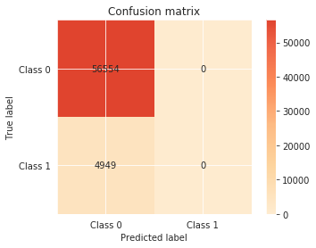

```
ROC Curve and AUC Plot:
```

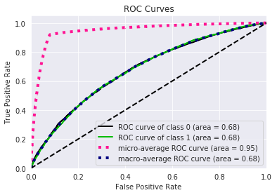

```python
Fit_Report(best_model, XTrain, YTrain, XTest, YTest)
```

> Micro- and macro-averages (for whatever metric) will compute slightly different things, and thus their interpretation differs. A macro-average will compute the metric independently for each class and then take the average (hence treating all classes equally), whereas a micro-average will aggregate the contributions of all classes to compute the average metric. In a multi-class classification setup, micro-average is preferable if you suspect there might be class imbalance (i.e you may have many more examples of one class than of other classes).  
> **micro:** Calculate metrics globally by counting the total number of times each class was correctly predicted and incorrectly predicted.  
> **macro:** Calculate metrics for each "class" independently, and find their unweighted mean. This does not take label imbalance into account.

```python
YTrain.value_counts()/len(YTrain)
```

```
0    0.919206
1    0.080794
Name: TARGET, dtype: float64
```

```python
train.TARGET.value_counts()/len(train)
```

```
0    0.919271
1    0.080729
Name: TARGET, dtype: float64
```

> The model is not catching the 1's, this is a *class imbalance problem* where the minority class is not being predicted by the model. The high accuracy value is based on the majority class, and is misleading. There are only .08 of 1's, in the data set. A good model needs to predict that 8%.

To address the class imbalance we have several options. We could over sample could oversample the ones or undersample the zeros, we could also try other models or we could use a model that will allow us to specify the weights or one that penalizes misclassification of the the ones. We will try several, first we will rerun the Logistic Regression and specifiy the weights, jsut to see if it will catch any ones.

#### Determine class weight, we'll use these weights in several places

```python
from sklearn.utils import class_weight
classes=np.unique(YTrain) # Get the classes
class_weights = class_weight.compute_class_weight('balanced', classes, YTrain) # compute the class weights
class_weight_dict = dict(zip(classes, class_weights)) #turn into a dictionary for call to LogisticRegression
class_weight_dict
```

```
{0: 0.543947782710983, 1: 6.188569128597304}
```

```python
weighted_model = LogisticRegression(C=paramCV['C'], max_iter=paramCV['max_iter'], class_weight=class_weight_dict)
```

```
             precision    recall  f1-score   support

          0       0.96      0.65      0.77     56554
          1       0.14      0.67      0.24      4949

avg / total       0.89      0.65      0.73     61503


Predictor: [Accuracy score: 0.6510]

Confusion Matrix:
```

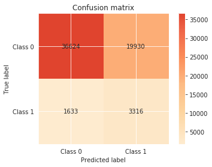

```
ROC Curve and AUC Plot:
```

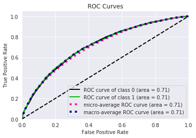

```python
Fit_Report(weighted_model, XTrain, YTrain, XTest, YTest)
```

> The number of 1's increased dramatically! We also got a 3% increase in our UAC metric. Next we will try several other models and approches to handling imbalanced classfication,and use our 71% AUC as our baseline for comparing other model results

# Evaluating Model Performance

## Implementation: Other Models

### Decision Tree

```python
from sklearn.tree import DecisionTreeClassifier
clsDT = DecisionTreeClassifier()
```

```python
param_grid = {"criterion": ["gini","entropy"],
             "min_samples_split": [10,15],
             "max_depth": [2,3,5],
             "min_samples_leaf":[5,7]}
```

```python
top_para = GridSearch_BestParam(XTrain, YTrain, clsDT, param_grid, cv=None)
top_score = sorted(top_para,key=itemgetter(1), reverse=True)
```

```python
paramCV = top_score[0].parameters
paramCV
```

```
{'criterion': 'entropy',
 'max_depth': 5,
 'min_samples_leaf': 5,
 'min_samples_split': 10}
```

```python
best_model = DecisionTreeClassifier(max_depth=paramCV['max_depth'],
                                    min_samples_split=paramCV['min_samples_split'],
                                    min_samples_leaf=paramCV['min_samples_leaf'],
                                    criterion=paramCV['criterion'],
                                    class_weight=class_weight_dict,
                                    random_state=RANDOM_SEED)
```

```
             precision    recall  f1-score   support

          0       0.96      0.65      0.77     56554
          1       0.14      0.66      0.23      4949

avg / total       0.89      0.65      0.73     61503


Predictor: [Accuracy score: 0.6531]

Confusion Matrix:
```

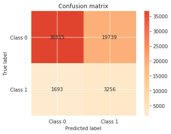

```
ROC Curve and AUC Plot:
```

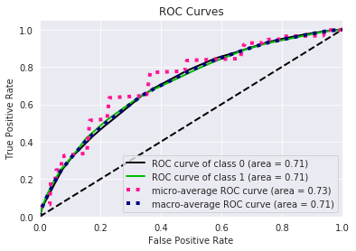

```python
Fit_Report(best_model, XTrain, YTrain, XTest, YTest)
```

### Random Forest

```python
from imblearn.over_sampling import SMOTE
```

```python
from sklearn.ensemble import RandomForestClassifier
```

#### Random Forest - Random search

```python
# specify parameters and distributions to sample from
param_dist = {"n_estimators" :[25,50,100,150],
              "max_depth": [3, None],
              "max_features": ['auto'],
              "min_samples_split": [2,5,10],
              "min_samples_leaf": [25,50,75],
              "bootstrap": [True, False],
              "criterion": ["gini", "entropy"]}

# run randomized search
n_iter_search = 10

clsRF = RandomForestClassifier(class_weight=class_weight_dict, random_state=RANDOM_SEED)

start = time()
random_search = RandomizedSearchCV(clsRF, param_distributions=param_dist, n_iter=n_iter_search, scoring='roc_auc', cv=3)

random_search.fit(XTrain, YTrain)
print("RandomizedSearchCV took %.2f seconds for %d candidates"
      " parameter settings." % ((time() - start), n_iter_search))
report(random_search.cv_results_)
paramCV=random_search.best_params_
```

```
RandomizedSearchCV took 883.40 seconds for 10 candidates parameter settings.
Model with rank: 1
Mean validation score: 0.743 (std: 0.002)
Parameters: {'n_estimators': 150, 'min_samples_split': 2, 'min_samples_leaf': 50, 'max_features': 'auto', 'max_depth': None, 'criterion': 'gini', 'bootstrap': False}

Model with rank: 2
Mean validation score: 0.740 (std: 0.002)
Parameters: {'n_estimators': 50, 'min_samples_split': 2, 'min_samples_leaf': 50, 'max_features': 'auto', 'max_depth': None, 'criterion': 'gini', 'bootstrap': False}

Model with rank: 3
Mean validation score: 0.740 (std: 0.001)
Parameters: {'n_estimators': 50, 'min_samples_split': 5, 'min_samples_leaf': 75, 'max_features': 'auto', 'max_depth': None, 'criterion': 'gini', 'bootstrap': False}
```

#### Using Weights

```python
#use the same parameters originally returned from randonsearchCV above
clsRF = RandomForestClassifier(n_estimators=paramCV['n_estimators'],
                            max_depth=paramCV['max_depth'],
                            max_features=paramCV['max_features'],
                            min_samples_split=paramCV['min_samples_split'],
                            min_samples_leaf=paramCV['min_samples_leaf'],
                            bootstrap=paramCV['bootstrap'],
                            criterion=paramCV['criterion'],
                            class_weight=class_weight_dict,
                            random_state=RANDOM_SEED)
```

```
             precision    recall  f1-score   support

          0       0.95      0.78      0.86     56554
          1       0.19      0.56      0.28      4949

avg / total       0.89      0.77      0.81     61503


Predictor: [Accuracy score: 0.8100]

Confusion Matrix:
```

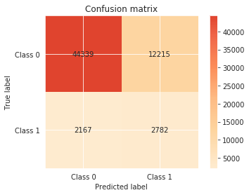

```
ROC Curve and AUC Plot:
```

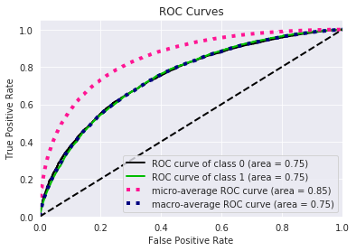

```python
Fit_Report(clsRF, XTrain, YTrain, XTest, YTest)
```

#### Using oversampling with SMOTE

At a high level, SMOTE creates synthetic observations of the minority class (bad loans) by:

Finding the k-nearest-neighbors for minority class observations (finding similar observations) Randomly choosing one of the k-nearest-neighbors and using it to create a similar, but randomly tweaked, new observation. After upsampling to a class ratio of 1.0, I should have a balanced dataset. There’s no need (and often it’s not smart) to balance the classes, but it magnifies the issue caused by incorrectly timed oversampling.

the right way: oversampling on only the training data.

```python
x_train, x_val, y_train, y_val = train_test_split(XTrain, YTrain,
                                                  test_size = .2,
                                                  random_state=RANDOM_SEED)
```

By oversampling only on the training data, none of the information in the validation data is being used to create synthetic observations. So these results should be generalizable. Let’s see if that’s true.

```python
sm = SMOTE(random_state=RANDOM_SEED, ratio = 1.0)
x_train_res, y_train_res = sm.fit_sample(x_train, y_train)
```

```python
'''
# specify parameters and distributions to sample from
param_dist = {"n_estimators" :[25,50,100,150],
              "max_depth": [3, None],
              "max_features": ['auto'],
              "min_samples_split": [2,5,10],
              "min_samples_leaf": [25,50,75],
              "bootstrap": [True, False],
              "criterion": ["gini", "entropy"]}


# run randomized search
n_iter_search = 10

clsRF = RandomForestClassifier(random_state=RANDOM_SEED)

start = time()
random_search = RandomizedSearchCV(clsRF, param_distributions=param_dist, n_iter=n_iter_search, scoring='roc_auc', cv=3)

random_search.fit(x_train_res, y_train_res)
print("RandomizedSearchCV took %.2f seconds for %d candidates"
      " parameter settings." % ((time() - start), n_iter_search))
report(random_search.cv_results_)
paramCV=random_search.best_params_
'''
```

[output not shown]

```python
# use the same parameters originally returned from randonsearchCV above
# excluding the class weights as oversampling should handle this now
clsRF = RandomForestClassifier(n_estimators=paramCV['n_estimators'],
                            max_depth=paramCV['max_depth'],
                            max_features=paramCV['max_features'],
                            min_samples_split=paramCV['min_samples_split'],
                            min_samples_leaf=paramCV['min_samples_leaf'],
                            bootstrap=paramCV['bootstrap'],
                            criterion=paramCV['criterion'],
                            random_state=RANDOM_SEED)
```

```python
clsRF.fit(x_train_res, y_train_res)
```

```
RandomForestClassifier(bootstrap=False, class_weight=None, criterion='gini',
            max_depth=None, max_features='auto', max_leaf_nodes=None,
            min_impurity_decrease=0.0, min_impurity_split=None,
            min_samples_leaf=50, min_samples_split=2,
            min_weight_fraction_leaf=0.0, n_estimators=150, n_jobs=1,
            oob_score=False, random_state=42, verbose=0, warm_start=False)
```

```python
from sklearn.metrics import recall_score
print ('Validation Results')
print (clsRF.score(x_val, y_val))
print (recall_score(y_val, clsRF.predict(x_val)))
print ('\nTest Results')
print (clsRF.score(XTest, YTest))
print (recall_score(YTest, clsRF.predict(XTest)))
```

```
Validation Results
0.9048006178610626
0.07570509648688768

Test Results
0.9059070289254183
0.07597494443321884
```

The validation results closely match the unseen test data results, which is exactly what I would want to see after putting a model into production.

Now let's finish our prediction

```
             precision    recall  f1-score   support

          0       0.92      0.98      0.95     56554
          1       0.24      0.08      0.12      4949

avg / total       0.87      0.91      0.88     61503


Predictor: [Accuracy score: 0.9356]

Confusion Matrix:
```

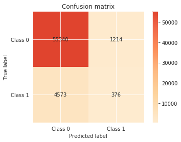

```
ROC Curve and AUC Plot:
```

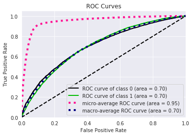

```python
Fit_Report(clsRF, x_train_res, y_train_res, XTest, YTest)
```

### Neural Net

```python
from keras.models import Sequential
from keras.layers import Dense, Dropout, Activation
from keras import initializers
from keras import optimizers
from keras.layers.normalization import BatchNormalization
from keras import regularizers
from keras.wrappers.scikit_learn import KerasClassifier
from sklearn.model_selection import cross_val_score
from sklearn.preprocessing import LabelEncoder
from sklearn.model_selection import StratifiedKFold
from sklearn.preprocessing import StandardScaler
from sklearn.pipeline import Pipeline
import tensorflow as tf
```

```python
def as_keras_metric(method):
    import functools
    from keras import backend as K
    import tensorflow as tf
    @functools.wraps(method)
    def wrapper(self, args, **kwargs):
        """ Wrapper for turning tensorflow metrics into keras metrics """
        value, update_op = method(self, args, **kwargs)
        K.get_session().run(tf.local_variables_initializer())
        with tf.control_dependencies([update_op]):
            value = tf.identity(value)
        return value
    return wrapper

auc_roc = as_keras_metric(tf.metrics.auc)
recall = as_keras_metric(tf.metrics.recall)
```

```python
from sklearn.utils import class_weight
class_weights = class_weight.compute_class_weight('balanced',
                                                 np.unique(YTrain),
                                                 YTrain)

model = Sequential()
model.add(Dense(32, input_dim=164, activation='relu', kernel_initializer='normal'))
model.add(Dense(16, activation='relu', kernel_initializer='normal'))
model.add(Dense(units=1, activation='sigmoid', kernel_initializer='normal'))

model.compile(loss='binary_crossentropy',
              optimizer=optimizers.Adam(lr=0.001),metrics=[auc_roc])

model.fit(XTrain, YTrain, epochs=150,batch_size=512, class_weight=class_weight_dict)
```

```
<keras.callbacks.History at 0x7f379d7f7940>
```

```python
from sklearn.metrics import roc_curve
YTest_Pred = model.predict(XTest)
YTest_Pred_Bin = (YTest_Pred >= 0.5)
```

```python
YTest_Pred
```

```
array([[0.83],
       [0.22],
       [0.73],
       ...,
       [0.26],
       [0.4 ],
       [0.31]], dtype=float32)
```

```python
confusion_matrix(YTest,YTest_Pred_Bin)
```

```
array([[37128, 19426],
       [ 1566,  3383]])
```

```python
print(classification_report(YTest,YTest_Pred_Bin))
```

```
             precision    recall  f1-score   support

          0       0.96      0.66      0.78     56554
          1       0.15      0.68      0.24      4949

avg / total       0.89      0.66      0.74     61503
```

```python
#from sklearn.metrics import roc_curve
#YTest_Pred = model.predict(XTest).ravel()
fpr_keras, tpr_keras, thresholds_keras = roc_curve(YTest,YTest_Pred)
```

```python
from sklearn.metrics import auc
auc_keras = auc(fpr_keras, tpr_keras)
```

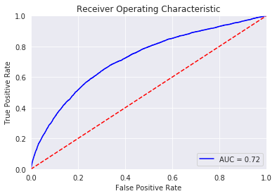

```python
plt.title('Receiver Operating Characteristic')
plt.plot(fpr_keras, tpr_keras, 'b', label = 'AUC = %0.2f' % auc_keras)
plt.legend(loc = 'lower right')
plt.plot([0, 1], [0, 1],'r--')
plt.xlim([0, 1])
plt.ylim([0, 1])
plt.ylabel('True Positive Rate')
plt.xlabel('False Positive Rate')
plt.show()
```

**NOTE: The ANN actually performs better when tested with only the important features, getting around .74 AUC, here with all features it's getting .72**

```python
ann_pred = model.predict_proba(test)#[:, 1]
```

```python
submit = app_test[['SK_ID_CURR']]
submit['TARGET'] = ann_pred

submit.head()
```

[output not shown]

```python
# Save the submission to a csv file
submit.to_csv('ANN_2.csv', index = False)
```

## XGBoost

```python
from xgboost import XGBClassifier
```

```python
from scipy import stats as st

# specify parameters and distributions to sample from
one_to_left = st.beta(10, 1)
from_zero_positive = st.expon(0, 50)

param_dist = {
    "n_estimators": [5, 10,20, 30],
    "max_depth": [3,6,10],
    "learning_rate": [.01, .02,.5],
    "colsample_bytree": one_to_left,
    "subsample": one_to_left,
    "gamma": st.uniform(0, 10),
    'reg_alpha': from_zero_positive,
    "min_child_weight": from_zero_positive,
}

# run randomized search
n_iter_search = 10

clsXGB = XGBClassifier(class_weight=class_weight_dict, nthread=4, scale_pos_weight=1,
                       objective= 'binary:logistic', random_state=RANDOM_SEED, cv=3)

start = time()
random_search = RandomizedSearchCV(estimator=clsXGB, param_distributions=param_dist,
                                   n_iter=n_iter_search)


random_search.fit(XTrain, YTrain)
print("RandomizedSearchCV took %.2f seconds for %d candidates"
      " parameter settings." % ((time() - start), n_iter_search))
report(random_search.cv_results_)
paramCV=random_search.best_params_
```

```
RandomizedSearchCV took 305.22 seconds for 10 candidates parameter settings.
Model with rank: 1
Mean validation score: 0.919 (std: 0.000)
Parameters: {'colsample_bytree': 0.9644472728421691, 'gamma': 6.912264934416453, 'learning_rate': 0.5, 'max_depth': 3, 'min_child_weight': 45.905603608711495, 'n_estimators': 30, 'reg_alpha': 10.168338716685366, 'subsample': 0.9144011957370972}

Model with rank: 2
Mean validation score: 0.919 (std: 0.000)
Parameters: {'colsample_bytree': 0.7155699278729062, 'gamma': 7.541681442434994, 'learning_rate': 0.5, 'max_depth': 6, 'min_child_weight': 47.057520609007376, 'n_estimators': 5, 'reg_alpha': 16.960013486270707, 'subsample': 0.9700569435281889}

Model with rank: 3
Mean validation score: 0.919 (std: 0.000)
Parameters: {'colsample_bytree': 0.8894621660656933, 'gamma': 5.891135481610251, 'learning_rate': 0.5, 'max_depth': 3, 'min_child_weight': 49.7138793652117, 'n_estimators': 30, 'reg_alpha': 11.182927669079442, 'subsample': 0.8709219154674406}

Model with rank: 3
Mean validation score: 0.919 (std: 0.000)
Parameters: {'colsample_bytree': 0.9421918876293933, 'gamma': 5.958929884335063, 'learning_rate': 0.5, 'max_depth': 3, 'min_child_weight': 1.2246659000015272, 'n_estimators': 20, 'reg_alpha': 96.1850004462342, 'subsample': 0.5123789606192651}

Model with rank: 3
Mean validation score: 0.919 (std: 0.000)
Parameters: {'colsample_bytree': 0.9513762109880417, 'gamma': 8.718746000338486, 'learning_rate': 0.01, 'max_depth': 10, 'min_child_weight': 20.342605190829786, 'n_estimators': 20, 'reg_alpha': 2.8751967475338005, 'subsample': 0.986191719122673}
```

```python
#use the same parameters originally returned from randonsearchCV above
clsXGB = XGBClassifier(
                n_estimators=paramCV['n_estimators'],
                max_depth=paramCV['max_depth'],
                learning_rate=paramCV['learning_rate'],
                colsample_bytree=paramCV['colsample_bytree'],
                subsample=paramCV['subsample'],
                gamma=paramCV['gamma'],
                reg_alpha=paramCV['reg_alpha'],
                min_child_weight=paramCV['min_child_weight'],
                class_weight=class_weight_dict,
                random_state=RANDOM_SEED)
```

```
             precision    recall  f1-score   support

          0       0.92      1.00      0.96     56554
          1       0.57      0.02      0.03      4949

avg / total       0.89      0.92      0.88     61503


Predictor: [Accuracy score: 0.9195]

Confusion Matrix:
```

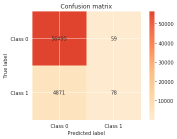

```
ROC Curve and AUC Plot:
```

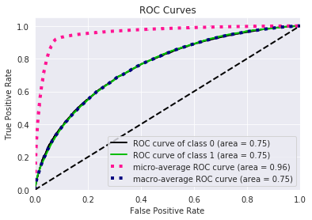

```python
Fit_Report(clsXGB, XTrain, YTrain, XTest, YTest)
```

## Feature Importance

```python
# List of features for later use
feature_list = list(features.columns)
# Get numerical feature importances

importances = list(clsXGB.feature_importances_)
# list of x locations for plotting
x_values = list(range(len(importances)))
# List of tuples with variable and importance
feature_importances = [(feature, round(importance, 2)) for feature, importance in zip(feature_list, importances)]
# Sort the feature importances by most important first
feature_importances = sorted(feature_importances, key = lambda x: x[1], reverse = True)
# List of features sorted from most to least important
sorted_importances = [importance[1] for importance in feature_importances]
sorted_features = [importance[0] for importance in feature_importances]
# Cumulative importances
cumulative_importances = np.cumsum(sorted_importances)
# List of features sorted from most to least important
sorted_importances = [importance[1] for importance in feature_importances]
sorted_features = [importance[0] for importance in feature_importances]
# Cumulative importances
cumulative_importances = np.cumsum(sorted_importances)
# Make a line graph
```

```python
fimp_df = pd.DataFrame()
fimp_df['Ranking']=x_values
fimp_df['Ranking'] = fimp_df['Ranking']+1
fimp_df['importance']=sorted_importances
fimp_df['cumulative']=cumulative_importances
fimp_df['feature']=sorted_features
fimp_df
```

|  | Ranking | importance | cumulative | feature |
| --- | --- | --- | --- | --- |
| 0 | 1 | 0.17 | 0.17 | EXT_SOURCE_3 |
| 1 | 2 | 0.14 | 0.31 | EXT_SOURCE_2 |
| 2 | 3 | 0.13 | 0.44 | ANNUITY LENGTH |
| 3 | 4 | 0.06 | 0.50 | DAYS_BIRTH |
| 4 | 5 | 0.05 | 0.55 | DAYS_EMPLOYED |
| 5 | 6 | 0.04 | 0.59 | AMT_GOODS_PRICE |
| 6 | 7 | 0.04 | 0.63 | DAYS_ID_PUBLISH |
| 7 | 8 | 0.03 | 0.66 | ANNUITY_INCOME_RATIO |
| 8 | 9 | 0.03 | 0.69 | CODE_GENDER_F |
| 9 | 10 | 0.03 | 0.72 | NAME_FAMILY_STATUS_Married |
| 10 | 11 | 0.02 | 0.74 | FLAG_OWN_CAR |
| 11 | 12 | 0.02 | 0.76 | AMT_INCOME_TOTAL |
| 12 | 13 | 0.02 | 0.78 | AMT_ANNUITY |
| 13 | 14 | 0.02 | 0.80 | REGION_RATING_CLIENT_W_CITY |
| 14 | 15 | 0.02 | 0.82 | LOAN_INCOME_RATIO |
| 15 | 16 | 0.02 | 0.84 | CODE_GENDER_M |
| 16 | 17 | 0.02 | 0.86 | NAME_EDUCATION_TYPE_Higher education |
| 17 | 18 | 0.01 | 0.87 | NAME_CONTRACT_TYPE |
| 18 | 19 | 0.01 | 0.88 | AMT_CREDIT |
| 19 | 20 | 0.01 | 0.89 | DAYS_REGISTRATION |
| 20 | 21 | 0.01 | 0.90 | FLAG_WORK_PHONE |
| 21 | 22 | 0.01 | 0.91 | FLAG_PHONE |
| 22 | 23 | 0.01 | 0.92 | REG_CITY_NOT_LIVE_CITY |
| 23 | 24 | 0.01 | 0.93 | DEF_30_CNT_SOCIAL_CIRCLE |
| 24 | 25 | 0.01 | 0.94 | DEF_60_CNT_SOCIAL_CIRCLE |
| 25 | 26 | 0.01 | 0.95 | DAYS_LAST_PHONE_CHANGE |
| 26 | 27 | 0.01 | 0.96 | FLAG_DOCUMENT_3 |
| 27 | 28 | 0.01 | 0.97 | FLAG_DOCUMENT_6 |
| 28 | 29 | 0.01 | 0.98 | AMT_REQ_CREDIT_BUREAU_QRT |
| 29 | 30 | 0.01 | 0.99 | DAYS_EMPLOYED_PERCENT |
| ... | ... | ... | ... | ... |
| 134 | 135 | 0.00 | 1.07 | ORGANIZATION_TYPE_Industry: type 9 |
| 135 | 136 | 0.00 | 1.07 | ORGANIZATION_TYPE_Insurance |
| 136 | 137 | 0.00 | 1.07 | ORGANIZATION_TYPE_Kindergarten |
| 137 | 138 | 0.00 | 1.07 | ORGANIZATION_TYPE_Legal Services |
| 138 | 139 | 0.00 | 1.07 | ORGANIZATION_TYPE_Medicine |
| 139 | 140 | 0.00 | 1.07 | ORGANIZATION_TYPE_Military |
| 140 | 141 | 0.00 | 1.07 | ORGANIZATION_TYPE_Mobile |
| 141 | 142 | 0.00 | 1.07 | ORGANIZATION_TYPE_Other |
| 142 | 143 | 0.00 | 1.07 | ORGANIZATION_TYPE_Police |
| 143 | 144 | 0.00 | 1.07 | ORGANIZATION_TYPE_Postal |
| 144 | 145 | 0.00 | 1.07 | ORGANIZATION_TYPE_Realtor |
| 145 | 146 | 0.00 | 1.07 | ORGANIZATION_TYPE_Religion |
| 146 | 147 | 0.00 | 1.07 | ORGANIZATION_TYPE_Restaurant |
| 147 | 148 | 0.00 | 1.07 | ORGANIZATION_TYPE_School |
| 148 | 149 | 0.00 | 1.07 | ORGANIZATION_TYPE_Security |
| 149 | 150 | 0.00 | 1.07 | ORGANIZATION_TYPE_Security Ministries |
| 150 | 151 | 0.00 | 1.07 | ORGANIZATION_TYPE_Services |
| 151 | 152 | 0.00 | 1.07 | ORGANIZATION_TYPE_Telecom |
| 152 | 153 | 0.00 | 1.07 | ORGANIZATION_TYPE_Trade: type 1 |
| 153 | 154 | 0.00 | 1.07 | ORGANIZATION_TYPE_Trade: type 2 |
| 154 | 155 | 0.00 | 1.07 | ORGANIZATION_TYPE_Trade: type 3 |
| 155 | 156 | 0.00 | 1.07 | ORGANIZATION_TYPE_Trade: type 4 |
| 156 | 157 | 0.00 | 1.07 | ORGANIZATION_TYPE_Trade: type 5 |
| 157 | 158 | 0.00 | 1.07 | ORGANIZATION_TYPE_Trade: type 6 |
| 158 | 159 | 0.00 | 1.07 | ORGANIZATION_TYPE_Trade: type 7 |
| 159 | 160 | 0.00 | 1.07 | ORGANIZATION_TYPE_Transport: type 1 |
| 160 | 161 | 0.00 | 1.07 | ORGANIZATION_TYPE_Transport: type 2 |
| 161 | 162 | 0.00 | 1.07 | ORGANIZATION_TYPE_Transport: type 4 |
| 162 | 163 | 0.00 | 1.07 | ORGANIZATION_TYPE_University |
| 163 | 164 | 0.00 | 1.07 | ORGANIZATION_TYPE_XNA |

164 rows × 4 columns

### Feature Selection

How does a model perform if we only use a subset of all the available features in the data? With less features required to train, the expectation is that training and prediction time is much lower — at the cost of performance metrics. From the visualization above, we see that the top five most important features contribute more than half of the importance of **all** features present in the data. This hints that we can attempt to *reduce the feature space* and simplify the information required for the model to learn. The code cell below will use the same optimized model you found earlier, and train it on the same training set *with only the top most important features*.

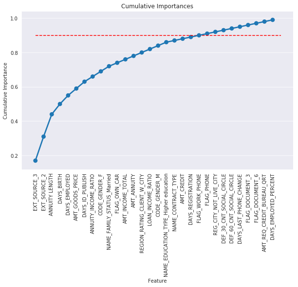

```python
sns.set_style("darkgrid")
plt.figure(figsize=(10, 6))
ax = sns.pointplot(x = "feature", y = "cumulative", data = fimp_df.iloc[:30,2:],ci=None)
ax.set_xticklabels(ax.get_xticklabels(), rotation=90)
plt.hlines(y = 0.90, xmin=0, xmax=30, color = 'r', linestyles = 'dashed')
plt.title('Cumulative Importances')
plt.xlabel('Feature')
plt.ylabel('Cumulative Importance');
plt.show();
```

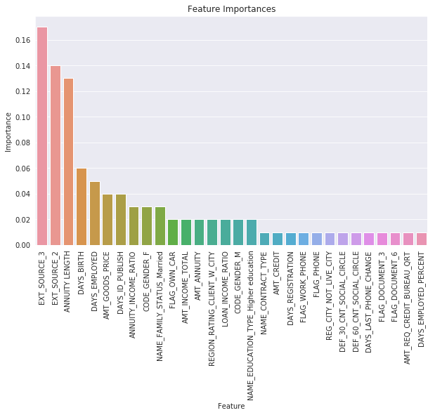

```python
sns.set_style("darkgrid")
plt.figure(figsize=(10,6))
ax = sns.barplot(x = "feature", y = "importance", data = fimp_df.iloc[:30,],ci=None)
ax.set_xticklabels(ax.get_xticklabels(), rotation=90)
plt.title('Feature Importances')
plt.xlabel('Feature')
plt.ylabel('Importance');
plt.show();
```

```python
# Find number of features for cumulative importance of 95%
# Add 1 because Python is zero-indexed
features_needed = np.where(cumulative_importances > 0.90)[0][0] + 1
print('Number of features for 95% importance:', features_needed)
```

```
Number of features for 95% importance: 22
```

```python
# Extract the names of the most important features
important_feature_names = [feature[0] for feature in feature_importances[0:features_needed]]
# Find the columns of the most important features
important_indices = [feature_list.index(feature) for feature in important_feature_names]
```

```python
# Create training and testing sets with only the important features
important_train_features = features.iloc[:, important_indices]
important_predict_features = test.iloc[:, important_indices]
# Sanity check on operations
print('Important train features shape:', important_train_features.shape)
print('Important test features shape:', important_predict_features.shape)
```

```
Important train features shape: (307511, 22)
Important test features shape: (48744, 22)
```

#### Let's repeat the XGBoost with the important features

```python
# Split the data into features and target label
imp_target = train['TARGET'].astype(np.int64)
```

```python
imp_features = important_train_features
```

```python
# Create a validation set to check training performance
XTrain_imp, XTest_imp, YTrain_imp, YTest_imp = train_test_split(
    imp_features, imp_target, test_size=0.2, random_state=RANDOM_SEED)
```

```python
#use the same parameters originally returned from randonsearchCV above
clsXGB = XGBClassifier(
                n_estimators=paramCV['n_estimators'],
                max_depth=paramCV['max_depth'],
                learning_rate=paramCV['learning_rate'],
                colsample_bytree=paramCV['colsample_bytree'],
                subsample=paramCV['subsample'],
                gamma=paramCV['gamma'],
                reg_alpha=paramCV['reg_alpha'],
                min_child_weight=paramCV['min_child_weight'],
                class_weight=class_weight_dict,
                random_state=RANDOM_SEED)
```

```
             precision    recall  f1-score   support

          0       0.92      1.00      0.96     56554
          1       0.60      0.02      0.03      4949

avg / total       0.89      0.92      0.88     61503


Predictor: [Accuracy score: 0.9195]

Confusion Matrix:
```

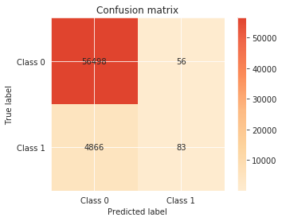

```
ROC Curve and AUC Plot:
```

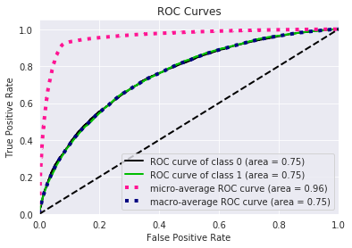

```python
Fit_Report(clsXGB, XTrain_imp, YTrain_imp, XTest_imp, YTest_imp)
```

```python
ann_pred = clsXGB.predict_proba(important_predict_features)[:, 1]
```

```python
ann_pred
```

```
array([0.46, 0.46, 0.46, ..., 0.46, 0.46, 0.46], dtype=float32)
```

```python
submit = app_test[['SK_ID_CURR']]
submit['TARGET'] = ann_pred

submit.head()
```

|  | SK_ID_CURR | TARGET |
| --- | --- | --- |
| 0 | 100001 | 0.462680 |
| 1 | 100005 | 0.462170 |
| 2 | 100013 | 0.455665 |
| 3 | 100028 | 0.455665 |
| 4 | 100038 | 0.459434 |

```python
# Save the submission to a csv file
submit.to_csv('ANN_baseline.csv', index = False)
```

# Phase 2

Leveraging additional data files